# Python_tutorial_01

Ji-Myoung Choi

2022-12

## 전체 강의의 목표 및 내용

### 강의의 내용

- Python을 이용한 텍스트 읽고 쓰기
- 텍스트 파일 내용 변환하기(정규식 활용)
- 텍스트 파일에서 정보 추출하기: 단어 목록, 네트워크 그래프 등
- 특수 형태 파일 포맷 처리하기: html, json, xml
- 웹 데이터 수집 후 처리하기
- 텍스트 파일 분석 도구 소개: AntConc

### 필요 도구

- Python
- Jupyter notebook
- Notepad++

## 텍스트 파일 읽고 쓰기

#### 1. 텍스트 파일 읽기

읽을 파일이 저장된 **위치-경로**와 **파일 이름**을 먼저 확인한다.

```python
filepath = 'data/moby_dick_melville.txt'

f = open(filepath, mode='r')
doc = f.readlines()
f.close()

len(doc)
```

```
## 22316
```

1. 1행: 읽을 파일의 경로를 지정하여 *filepath*라는 변수에 저장한다.
2. 3행: **open()** 함수로 파일을 읽을 준비를 한다. 함수 이름은 open이지만 실제 파일을 읽지 않고 파일의 위치와 준비 모드(‘r’: read)에 대한 정보를 *f*라는 객체에 저장한다.
3. 4행: **readlines()** 함수로 텍스트 파일을 실제 읽어들여서 *doc*이라는 변수에 저장한다. **readlines**는 파일의 라인들을 모두 읽으라는 의미이다.
4. 5행: 파일을 읽은 후에는 **close()** 함수로 열려있는 *f* 객체를 닫아준다. **open()**과 **close()**는 한 쌍을 이룬다.
5. 7행: 파일이 제대로 읽혔는지 **len()** 함수로 확인해 본다. len은 변수에 저장된 목록의 갯수를 세는 함수이다. 이 때 len() 함수는 파일의 총 라인 수(즉 엔터가 들어간 수)를 계산한다. 총 22,316행임을 알 수 있다. 확인해 보려면 에디터로 같은 파일을 열어서 마지막 행의 라인 수를 확인한다.

#### 2. 읽은 파일의 내용 들여다보기

- 텍스트 파일을 읽은 후 파일의 내용을 살펴보려면 **print(변수)** 함수를 사용할 수 있다.
- 그러나 읽은 텍스트가 총 2만 라인 이상이므로 출력 범위를 넘어선다. 이 때는 파일의 일부분(첫 부분 혹은 끝부분)만 출력할 수 있다.
- 변수[시작점:끝점] 과 같이 인덱스를 사용하여 슬라이싱(slicing)을 한다(슬라이싱: 저장된 문서의 일부분만 잘라낸다는 의미).

```python
doc[:10]
```

```
## ['\ufeffThe Project Gutenberg eBook of Moby-Dick; or The Whale, by Herman Melville\n', '\n', 'This eBook is for the use of anyone anywhere in the United States and\n', 'most other parts of the world at no cost and with almost no restrictions\n', 'whatsoever. You may copy it, give it away or re-us…
```

1. 1행: [:10]는 doc의 첫 번째 라인부터 9번째 라인까지 총 10개의 라인을 출력하라는 의미이다. **doc[0:10]**과 같이 표현할 수도 있다. 파이썬의 인덱스는 0에서 시작한다. 즉 0, 1, 2, 3, 4, 5, 6, 7, 8, 9까지 10개 라인을 출력한다.  
   *print(doc[:10])*와 같이 사용해도 되고 그냥 *doc[:10]*만 사용해도 된다.

```python
doc[1000:1010]
```

```
## ['wherefore it was that after having repeatedly smelt the sea as a\n', 'merchant sailor, I should now take it into my head to go on a whaling\n', 'voyage; this the invisible police officer of the Fates, who has the\n', 'constant surveillance of me, and secretly dogs me, and influences me in\n', '…
```

1. 1행: [1000:1010]는 doc의 1000번째 라인부터 1009번째 라인까지 읽으라는 의미이다. 즉, 1000, 1001, 1002, 1003, 1004, 1005, 1006, 1007, 1008, 1009번째 라인까지 총 10개 라인을 출력한다.

```python
doc[500]
```

```
## '  his ponderous tail. ... Their fixed jav’lins in his side he wears,\n'
```

#### 3. 텍스트 파일을 읽는 다른 방법

```python
filepath = 'data/moby_dick_melville.txt'

with open(filepath, mode='r') as f:
    doc = f.readlines()

len(doc)
```

```
## 22316
```

1. 1행: 읽을 파일의 경로를 지정하여 *filepath*라는 변수에 저장한다.
2. 3행: **with**와 함께 **open()** 함수를 이용하여 파일을 읽을 준비를 하고 이 정보를 f라는 객체에 저장한다. **with**로 시작한 구문은 끝에 :를 추가하여 구문이 완료되지 않았음을 표시한다.
3. 4행: **readlines()** 함수로 파일을 실제로 읽어 파일 내용을 변수 doc에 저장한다. **with…** 구문을 사용할 경우에는 **close()**로 *f* 객체를 닫지 않아도 된다. 자동으로 닫힌다.
4. 6행: 파일을 잘 읽었는지 len() 함수로 확인해 본다. 위와 동일한 정보가 저장되었음을 알 수 있다.

###### 파일의 처음 10개 라인만 출력하고 싶을 때는 것은 아래와 같이 **for…** 구문을 이용하여 구현할 수 있다.

```python
filepath = 'data/moby_dick_melville.txt'

with open(filepath, 'r') as f:
    doc = f.readlines()
    for line in doc[:10]:
        print(line)
```

```
## The Project Gutenberg eBook of Moby-Dick; or The Whale, by Herman Melville
##
##
##
## This eBook is for the use of anyone anywhere in the United States and
##
## most other parts of the world at no cost and with almost no restrictions
##
## whatsoever. You may copy it, give it away or re-use it under the terms
##
## of the Project Gutenberg License included with this eBook or online at
##
## www.gutenberg.org. If you are not located in the United States, you
##
## will have to check the laws of the country where you are located before
##
## using this eBook.
```

1. 1행: 읽을 파일의 경로를 지정하여 *filepath*라는 변수에 저장한다.
2. 3행: **with**와 함께 **open()** 함수를 이용하여 파일을 읽을 준비를 하고 이 정보를 **f**라는 객체에 저장한다. **with**로 시작한 구문은 끝에 :를 추가하여 구문이 완료되지 않았음을 표시한다.
3. 4행: **readlines()** 함수로 파일을 실제로 읽어 파일 내용을 변수 doc에 저장한다. **with…** 구문을 사용할 경우에는 **close()**로 *f* 객체를 닫지 않아도 된다. 자동으로 닫힌다.
4. 5행: *for [a] in [A]* 구문은 “A 리스트에 있는(in) 각 요소 a에 대해서(for) 차례대로”라는 의미이다. 즉 “doc 문서 중 10번째 라인까지 슬라이싱한 것에서 각 라인에 대해서”라는 의미이다. for … in … 구문은 끝에 :를 붙여 명령이 끝나지 않았음을 알려준다.
5. 6행: *for* 구문 다음 줄은 들여쓰기를 한다. 위에서 가지고 온 각 라인을 차례대로 출력한다. 출력 결과는 1행에서 10행까지이다.

#### 4. 읽은 텍스트에서 불필요한 기호나 공백을 제거하기

- 각 라인 끝의 기호(엔터 즉 라인의 끝을 표시)와 첫 번째 라인의 문자(특수문자)를 제거한다.

```python
filepath = 'data/moby_dick_melville.txt'

with open(filepath, mode='r') as f:
    doc = f.readlines()

print(doc[:10])
```

```
## ['\ufeffThe Project Gutenberg eBook of Moby-Dick; or The Whale, by Herman Melville\n', '\n', 'This eBook is for the use of anyone anywhere in the United States and\n', 'most other parts of the world at no cost and with almost no restrictions\n', 'whatsoever. You may copy it, give it away or re-us…
```

```python
with open(filepath, mode='r') as f:
    new_lines = []
    for line in f:
        new_line = line.strip()
        new_line = new_line.replace('\ufeff', '')
        new_lines.append(new_line)

new_lines[:10]
```

```
## ['The Project Gutenberg eBook of Moby-Dick; or The Whale, by Herman Melville', '', 'This eBook is for the use of anyone anywhere in the United States and', 'most other parts of the world at no cost and with almost no restrictions', 'whatsoever. You may copy it, give it away or re-use it under the…
```

##### 텍스트 파일을 읽는 3개 함수(read vs. readline vs. readlines)

- **read()**: 텍스트 파일 전체를 하나로 읽어 하나의 문자열(string)으로 저장한다.. 이 때 각 라인 끝에는 ’’이 추가되어 라인 구분자 역할을 한다.
- **readline()**: 텍스트 파일을 한 줄만 읽어 문자열로 저장한다.
- **readlines()**: 텍스트 파일의 전체 라인을 읽어 문자열로 이루어진 리스트(list)로 저장한다.

```python
filepath = 'data/moby_dick_melville.txt'

with open(filepath, mode='r') as f:
    doc_from_read = f.read()
```

1. 4행: **read()** 함수로 파일 전체를 하나의 덩어리로 읽어들인 후 *doc_from_read* 변수에 저장한다.

```python
print(len(doc_from_read)); print(doc_from_read[:500])
```

```
## 1238355
## The Project Gutenberg eBook of Moby-Dick; or The Whale, by Herman Melville
##
## This eBook is for the use of anyone anywhere in the United States and
## most other parts of the world at no cost and with almost no restrictions
## whatsoever. You may copy it, give it away or re-use it under the terms
## of the Project Gutenberg License included with this eBook or online at
## www.gutenberg.org. If you are not located in the United States, you
## will have to check the laws of the country where you are located befor
```

1. 5행: *doc_from_read* 변수의 길이, 즉 읽은 텍스트의 전체 문자 수를 출력한다. 그리고 *doc_from_read* 변수의 499번째 문자까지만 출력한다.

```python
filepath = 'data/moby_dick_melville.txt'

with open(filepath, mode='r') as f:
  doc_from_readline = f.readline()
```

1. 4행: **readline()** 함수로 파일의 한 행, 즉 첫 번째 라인만 읽은 후 *doc_from_readline* 변수에 저장한다.

```python
print(len(doc_from_readline)); print(doc_from_readline)
```

```
## 76
## The Project Gutenberg eBook of Moby-Dick; or The Whale, by Herman Melville
```

1. 5행: *doc_from_readline* 변수에 저장한 라인의 문자 수를 출력한다. 그리고 *doc_from_readline* 변수에 저장된 라인을 전체 출력한다.

```python
filepath = 'data/moby_dick_melville.txt'

with open(filepath, mode='r') as f:
    doc_from_readlines = f.readlines()
```

1. 4행: **readlines()** 함수로 파일의 전체 행을 읽은 후 *doc_from_readlines* 변수에 저장한다.

```python
print(len(doc_from_readlines)); print(doc_from_readlines[:10])
```

```
## 22316
## ['\ufeffThe Project Gutenberg eBook of Moby-Dick; or The Whale, by Herman Melville\n', '\n', 'This eBook is for the use of anyone anywhere in the United States and\n', 'most other parts of the world at no cost and with almost no restrictions\n', 'whatsoever. You may copy it, give it away or re-us…
```

1. 5행: *doc_from_readlines* 변수에 저장된 라인의 수를 출력한다. 그리고 *doc_from_readlines* 변수에 저장된 전체 라인 중 9번째 라인(즉 총 10행)까지 출력한다.

따라서 파일을 라인 구분 필요없이 통으로 읽을 때에는 **read()** 함수를, 라인별로 읽을 필요가 있을 때에는 **readlines()** 함수를 이용한다.

#### 5. 읽은 파일을 파일 이름을 바꾸어 그대로 저장하기

```python
filepath = 'data/moby_dick_melville.txt'

with open(filepath, mode='r') as f:
    doc = f.readlines()

filepath_1 = 'data/moby_dick_melville_duplicate.txt'

f = open(filepath_1, mode='w')
f.writelines(doc)
f.close()
```

1. 1-4행: 파일을 읽어 *doc* 변수에 저장한다.
2. 6행: 저장할 파일의 이름을 지정하여 filepath_1 변수에 저장한다.
3. 8행: **open()** 함수로 저장할 위치와 쓰기 모드(‘w’ = write)를 설정한 후 f 변수에 할당한다.
4. 9행: writelines() 함수로 *doc*의 내용을 실제 파일에 쓴다.
5. 10행: close() 함수로 열려있는 *f* 객체를 닫아준다.

##### 다음과 같이 실행할 수도 있다. 파일을 읽을 때와 같으며 open() 함수의 작업 모드만 ’r’에서 ’w’로 바꾸어주면 된다.

```python
filepath_1 = 'data/moby_dick_melville_1.txt'

with open(filepath_1, 'w') as f:
    f.writelines(doc)
```

#### 6. 텍스트에서 본문(Chapter 1부터 Epilogue까지)만 새로운 텍스트 파일로 저장하기

```python
filepath = 'data/moby_dick_melville.txt'
with open(filepath, mode='r') as f:
    doc = f.readlines()

doc_reduced = doc[844:21959]

filepath_2 = 'data/moby_dick_melville_only_body.txt'
with open(filepath_2, 'w') as f:
    f.writelines(doc_reduced)
```

#### 7. 파일을 두 개 이상 읽는 방법

- 파일들이 위치한 디렉토리(폴더)를 지정하고
- 그 디렉토리에 있는 파일들의 목록을 읽은 후
- 목록에 있는 파일들을 **read()**나 **readlines()**로 읽어서 변수에 저장한다.

```python
import os

target_dir = 'data'
target_files = os.listdir(target_dir)

print(target_files)
```

```
## ['chat_words.txt', 'dracula_Stoker.txt', 'english_wordlist.txt', 'frankenstein_shelley.txt', 'moby_dick_linenum_title.txt', 'moby_dick_melville.txt', 'moby_dick_melville_1.txt', 'moby_dick_melville_chapter_titles.txt', 'moby_dick_melville_duplicate.txt', 'moby_dick_melville_only_body.txt', 'test_…
```

1. 1행: **os**(operating system) 모듈을 탑재한다. **os** 모듈은 디렉토리 검색, 디렉토리 만들기/삭제하기 등과 같은 운영 체제와 관련된 기능을 제공한다.
2. 3행: 읽을 파일들이 있는 디렉토리를 지정하여 *target_dir* 변수에 저장한다. 즉 이 디렉토리 내의 파일을 읽게 된다.
3. 4행: **listdir()** 함수로 이 디렉토리 내의 파일 목록을 읽는다.
4. 6행: 읽어온 파일 목록을 출력한다.

```python
all_docs = []
for file in target_files:
    with open(os.path.join(target_dir, file), 'r') as f:
        doc = f.read()
        all_docs.append(doc)

len(all_docs)
```

```
## 16
```

1. 1행: 읽어온 파일들을 저장할 변수를 미리 설정한다. [] 내에 하나씩 읽어온 텍스트가 차례로 저장된다. [] 기호는 리스트(list)를 만들라는 의미이다.
2. 2행: *for…* 구문으로 읽어올 대상 파일들을 하나씩 호출한다. 즉 **target_files**에 저장된 파일 이름을 하나씩 불러와서 **file**에 할당한다.
3. 3-4행: *with open()* 구문 블록으로 파일을 하나씩 읽어 변수 **doc**에 저장한다. 파일을 읽을 때 파일 이름 외에 경로 정보가 필요하므로 target_dir의 경로 정보와 file에 저장된 파일 이름을 **os.path.join()** 함수로 결합한다. 결합한 결과는 ‘data/moby_dick_melville_1.txt’ 등과 같은 형태이다.
4. 5행: **doc** 변수에 저장된 내용을 1행에서 만든 **all_docs** 리스트에 순차적으로 저장한다. 리스트에 새로운 내용을 추가할 때는 *append()* 함수를 사용한다.
5. 7행: *len()* 함수로 **all_docs** 내에 저장된 텍스트의 수를 확인하여 제대로 다 읽어왔는지 확인한다.

#### 8. 텍스트에서 챕터 제목 라인만 출력하기

- 챕터 제목의 형식을 먼저 확인하고 이 형식에 맞게 챕터 제목을 만든다.
- 이 챕터 제목을 읽은 문서에서 찾는다.

```python
filepath = 'data/moby_dick_melville.txt'

with open(filepath, mode='r') as f:
    doc = f.readlines()

doc = doc[844:21959]

chapter_name = 'CHAPTER'

chapter_titles = []
for line in doc:
    if chapter_name in line:
        chapter_titles.append(line)

print(chapter_titles)
```

```
## ['CHAPTER 1. Loomings.\n', 'CHAPTER 2. The Carpet-Bag.\n', 'CHAPTER 3. The Spouter-Inn.\n', 'CHAPTER 4. The Counterpane.\n', 'CHAPTER 5. Breakfast.\n', 'CHAPTER 6. The Street.\n', 'CHAPTER 7. The Chapel.\n', 'CHAPTER 8. The Pulpit.\n', 'CHAPTER 9. The Sermon.\n', 'CHAPTER 10. A Bosom Friend.\n', …
```

```python
with open('data/moby_dick_melville_chapter_titles.txt', 'w') as f:
  f.writelines(chapter_titles)
```

1. 1행: *with open()* 구문으로 파일을 쓸 준비를 한다. 쓸 파일의 이름을 따로 변수로 만들지 않고 쓸 파일 이름을 바로 *open()* 함수에 지정할 수도 있다. ’data/moby_dick_melville_chapter_titles.txt’가 새로 쓸 파일의 이름이다.
2. 2행: **chapter_titles** 내용을 위 파일에 직접 쓴다. 즉 저장한다.

#### 9. 챕터 제목과 챕터 제목이 들어간 라인 번호를 같이 저장하기

```python
chapter_name = 'CHAPTER'

chapter_line_num = 0
chapter_titles = []
for line in doc:
    chapter_line_num += 1

    if chapter_name in line:
        chapter_titles.append((chapter_line_num, line.strip()))

print(chapter_titles)
```

```
## [(1, 'CHAPTER 1. Loomings.'), (202, 'CHAPTER 2. The Carpet-Bag.'), (336, 'CHAPTER 3. The Spouter-Inn.'), (906, 'CHAPTER 4. The Counterpane.'), (1050, 'CHAPTER 5. Breakfast.'), (1128, 'CHAPTER 6. The Street.'), (1213, 'CHAPTER 7. The Chapel.'), (1307, 'CHAPTER 8. The Pulpit.'), (1399, 'CHAPTER 9. …
```

1. 1행: 챕터 제목 형식을 찾아 *chapter_name* 변수에 저장한다. 읽은 파일에서 챕터의 제목은 대문자 CHAPTER로 시작하는 라인들이다.
2. 3행: 챕터 라인 번호를 0으로 지정해 놓는다. 라인을 1부터 차례대로 읽으면서(즉 +=1: 1씩 더해가면서) 챕터 제목이 있는 라인에 도달했을 때 그 라인 번호를 chapter_line_num에 저장하고, 쳅터 제목이 없을 때에는 그냥 넘어간다.
3. 4행: 찾은 챕터 제목을 저장할 빈 리스트 []를 변수 *chapter_titles*에 할당한다.
4. 5행: *doc* 문서의(**in**) 각 라인 *line*에 대해(**for**)
5. 6행: 라인을 1부터 차례대로 읽으면서(즉 +=1: 1씩 더해가면서)
6. 8행: 만약(**if**) 이 라인에 chapter_name, 즉 ’CHAPTER’라는 문자열이 포함되어(**in**) 있으면
7. 9행: 해당 라인의 번호와 *line*을 튜플(tuple)로 만든 후에 *chapter_titles*에 차례대로 저장한다. 이 때 *line*에서 앞뒤 불필요한 공백 등을 제거하기 위해 *strip()* 함수를 사용한다.
8. 11행: *chapter_titles*룰 출력한다.

#### 10. 같은 정보를 정규식(regular expressions)을 이용하여 추출하기

- 정규식에 대한 자세한 내용은 tutorial_02에서 다룬다.

```python
import re

chapter_name = '^CHAPTER \d+'

chapter_titles = []
for line in doc:
    matched = re.search(chapter_name, line)
    if matched:
        match_str = matched.string.strip()
        chapter_titles.append(match_str)

print(chapter_titles)
```

```
## ['CHAPTER 1. Loomings.', 'CHAPTER 2. The Carpet-Bag.', 'CHAPTER 3. The Spouter-Inn.', 'CHAPTER 4. The Counterpane.', 'CHAPTER 5. Breakfast.', 'CHAPTER 6. The Street.', 'CHAPTER 7. The Chapel.', 'CHAPTER 8. The Pulpit.', 'CHAPTER 9. The Sermon.', 'CHAPTER 10. A Bosom Friend.', 'CHAPTER 11. Nightgo…
```

#### 11. 챕터 제목과 챕터 제목이 위치한 라인 정보를 텍스트 파일로 내보내기

```python
chapter_name = 'CHAPTER'

chapter_line_num = 0
chapter_titles = []
for line in doc:
    chapter_line_num += 1

    if chapter_name in line:
        chapter_titles.append((chapter_line_num, line.strip()))

with open('data/moby_dick_linenum_title.txt', 'w') as f:
  for linenum, title in chapter_titles:
      line_and_title = str(linenum) + "\t" + title + '\n'
      f.write(line_and_title)
```

[output not shown]

[output cut: 95 more lines]

```
## 54
## 58
## 31
## 31
## 37
## 34
## 29
## 48
## 30
## 28
## 49
## 33
## 40
## 41
## 41
```

#### 12. 이미 저장되어 있는 파일에 새로운 내용을 이어서 저장하기

```python
filepath = 'data/test_file.txt'
sent = 'Moby-Dick; or, The Whale is an 1851 novel by American writer Herman Melville.'

with open(filepath, 'w', encoding='utf-8') as f:
  f.write(sent)
```

```
## 77
```

```python
sents_added = \
"""\nThe book is the sailor Ishmael's narrative of the obsessive quest of Ahab,\
captain of the whaling ship Pequod,\
for revenge against Moby Dick, the giant white sperm whale that on the ship's previous voyage bit off Ahab's leg at the knee.\n\
A contribution to the literature of the American Renaissance, Moby-Dick was published to mixed reviews, was a commercial failure,\
and was out of print at the time of the author's death in 1891."""

with open(filepath, 'a', encoding='utf-8') as f:
    f.write(sents_added)
```

```
## 428
```

1. 1행: 저장할 텍스트 파일의 경로와 이름을 *filepath* 변수에 저장한다.
2. 2행: ’Moby-Dick; or, The Whale is an 1851 novel by American writer Herman Melville.’을 *sent*에 저장한다.
3. 4-5행: 위에서 지정한 경로명 파일에 *sent*를 저장한다.
4. 7-12행: 새 문장들을 *sents_added*에 저장한다. ’’은 엔터 기호로서 해당 위치에 엔터를 삽입하라는 의미이다.
5. 15행: **with open()** 함수로 1행에서 지정한 파일을 *f* 객체로 연다. 이 때 **open()**에 ‘w’ 대신 ‘a’ (append)를 지정하여 이미 저장된 파일 내용에 새 내용을 추가한다는 것을 알려준다.
6. 16행: 5행과 같은 방식으로 *sents_added*를 저장한다.

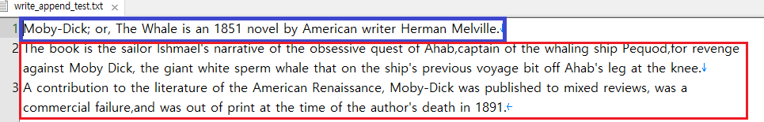

##### Tip

- *for…* 구문 대신 아래와 같이 보다 간단한 표현식으로 챕터 제목을 추출하는 방법도 있다. 이를 list comprehension이라고 한다.

```python
import re

chapter_name = '^CHAPTER \d+'

chapter_titles = [line.strip() for line in doc if re.search(chapter_name, line)]

print(chapter_titles)
```

```
## ['CHAPTER 1. Loomings.', 'CHAPTER 2. The Carpet-Bag.', 'CHAPTER 3. The Spouter-Inn.', 'CHAPTER 4. The Counterpane.', 'CHAPTER 5. Breakfast.', 'CHAPTER 6. The Street.', 'CHAPTER 7. The Chapel.', 'CHAPTER 8. The Pulpit.', 'CHAPTER 9. The Sermon.', 'CHAPTER 10. A Bosom Friend.', 'CHAPTER 11. Nightgo…
```

#### 13. 종합

data 폴더에 저장되어 있는 파일들 중 frankenstein_shelley, dracula_Stoker, moby_dick_melville 등 3개의 파일을 읽어, 챕터 제목과 챕터 제목이 위치한 라인 번호를 추출한 후, 결과를 각각의 파일로 저장하기

```python
import os

target_files = ['frankenstein_shelley.txt', 'dracula_Stoker.txt', 'moby_dick_melville.txt']
target_dir = 'data'
all_filenames = os.listdir(target_dir)
# print(all_filenames)


# *all_filenames*에 저장된 파일들 중 *target_files*의 이름과 일치하는 파일들만 고른 후 이 파일들의 경로 정보를 얻는다.
target_files_path = []
for filename in all_filenames:
    if filename in target_files:
        file_path = os.path.join(target_dir, filename)
        target_files_path.append(file_path)

# print(target_files_path)


chapter_name = 'CHAPTER'
all_books_chapter_titles = []
for file_path in target_files_path:
    with open(file_path, 'r') as f:
        doc = f.readlines()
        chapter_line_num = 0
        chapter_titles = []
        for line in doc:
            chapter_line_num += 1
            if chapter_name in line:
                chapter_titles.append((chapter_line_num, line.strip()))
    all_books_chapter_titles.append(chapter_titles)


write_files_path = []
for filename in target_files:
    new_filename = 'titles_' + filename
    new_filepath = os.path.join(target_dir, new_filename)
    write_files_path.append(new_filepath)


for chapter_title, write_path in zip(all_books_chapter_titles, write_files_path):
    with open(write_path, 'w') as f:
        for linenum, title in chapter_title:
            line_and_title = str(linenum) + "\t" + title + '\n'
            f.write(line_and_title)
```

[output not shown]

[output cut: 332 more lines]

```
## 54
## 58
## 31
## 31
## 37
## 34
## 29
## 48
## 30
## 28
## 49
## 33
## 40
## 41
## 41
```

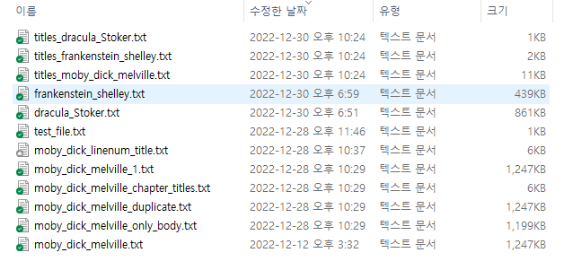

#### **zip()** 함수의 작동 원리는 아래와 같다.

```python
numbers = [1, 2, 3]
letters = ['a', 'b', 'c']
for pair in zip(numbers, letters):
  print(pair)
```

```
## (1, 'a')
## (2, 'b')
## (3, 'c')
```

1. 1-2행: 숫자 리스트 [1, 2, 3]과 문자 리스트 [‘a’, ‘b’, ‘c’]를 만들어 *numbers*와 *letters*에 저장한다.
2. 3행: **zip()** 함수로 두 개 리스트를 묶고 두 개 리스트의 요소들을 하나씩 쌍으로 꺼내어 *pair*에 할당한 후
3. 4행: *pair*를 차례대로 출력한다. numbers의 요소들과 letters의 요소들이 하나씩 쌍 (숫자, 문자)의 형태로 묶인 것을 볼 수 있다.

```python
numbers = [1, 2, 3]
letters = ['a', 'b', 'c']
for pair in zip(numbers, letters):
  num = pair[0]
  lett = pair[1]
  print(num, "is a number."); print(lett, "is a letter.")
```

```
## 1 is a number.
## a is a letter.
## 2 is a number.
## b is a letter.
## 3 is a number.
## c is a letter.
```

1. 4-5행: *pair*가 숫자와 문자가 하나씩 묶인 쌍이므로 각 쌍의 첫 번째 요소를 [0]번째 인덱스로 추출하고, 두 번째 요소를 [1]번째 인덱스로 추출하여 *num*과 *lett*에 각각 할당한다.
2. 6행: *num*과 *lett*을 각각 출력하되, “*num* is a number.”와 같은 형태로 출력한다.